# S6b: verifica della regola di ricaduta del modello marginalizzato

Roadmap Morris 2019, ramo morris-v4

Data di Pubblicazione

20 ottobre 2026

## In breve: la regola che corregge il modello marginalizzato regge, e quale metodo raccomandiamo nella Figura 1?

**A cosa serviva.** Nello step precedente abbiamo corretto il modello marginalizzato multilivello con una regola: se l’algoritmo non converge, o se la stima di quanto cresce nel tempo la variabilità tra soggetti finisce sul limite (zero), si usa il modello senza quella crescita. La regola era stata costruita su dati in cui la variabilità cresce pochissimo, dove il modello di ricaduta è quasi giusto. Abbiamo controllato due cose: se il risultato dipende dalla soglia che decide “sul limite”, e se la regola resta tarata quando la variabilità cresce davvero e il modello di ricaduta è sbagliato. Da qui dipende quale metodo raccomandare nella Figura 1.

**Cosa abbiamo trovato.**

1. **La soglia della regola non conta.**
   - Con una soglia dieci volte più piccola o dieci volte più grande cambia il modello usato in circa 20.000 dei 1,69 milioni di dataset già simulati; lì i due modelli danno quasi la stessa stima.
   - Falsi positivi e capacità di trovare un effetto vero si spostano al più di circa un millesimo di test su 100, cioè in modo trascurabile; nessuna delle 156 frasi di confronto del paper cambia.
2. **Quando la variabilità tra soggetti cresce davvero, il modello marginalizzato corretto resta tarato in tutte le 384 situazioni nuove.**
   - Abbiamo simulato 768.000 dataset in quattro scenari nuovi: dati generati sulla scala della popolazione, con deviazione standard latente che in 10 visite passa da 1 a 1,9 oppure a 3,25 (nello studio arriva a 1,09); dati generati dal modello misto, con una pendenza casuale nel tempo 10 o 40 volte più variabile che nello studio.
   - Con la distribuzione t non supera mai chiaramente 7,5 falsi positivi su 100; in media ne fa da 5,2 a 5,8 su 100, a seconda dello scenario.
   - Senza la correzione sbaglierebbe: supera chiaramente la soglia in 8 situazioni, quasi tutte con 10 visite nei dati del modello misto.
3. **La regola interviene molto più spesso di quanto mi aspettassi, ma senza danno.**
   - Usa il modello senza crescita in un dataset su tre fino a uno su due, soprattutto perché l’algoritmo non converge con 2-3 visite o con pochi soggetti; con molti soggetti e 8-10 visite succede in 6-37 dataset su 100.
   - Dove interviene, i falsi positivi restano 5 su 100, e la capacità di trovare un effetto vero cala di meno di mezzo test su 100.
4. **La correzione di Fay e Graubard con la distribuzione t, che oggi è la regola consigliata, esce di taratura in uno scenario nuovo.**
   - Sulla scala della popolazione, con la deviazione standard latente che arriva a 3,25 e fino a 25 soggetti, fa da 7 a 10 falsi positivi su 100; in due situazioni (15 soggetti e 6 visite, 25 soggetti e 4 visite) supera chiaramente 7,5, con 10 falsi positivi su 100.
   - Mettendo insieme le simulazioni dello studio e quelle nuove (1.896 situazioni), il modello marginalizzato corretto con la t è l’unica strategia che non supera mai chiaramente la soglia.

**Cosa devi decidere.**

1. **Quale metodo raccomandiamo nella Figura 1? Consiglio: il modello marginalizzato multilivello con il controllo di convergenza e la distribuzione t, a ogni numero di soggetti e di visite, con la correzione di Fay e Graubard con la t citata come alternativa.**
   - Il principio è quello che hai già accettato: chi analizza i dati non sa come sono stati generati, quindi la raccomandazione deve reggere in tutte le situazioni simulate. Si escludono i metodi che anche una sola volta superano chiaramente 7,5 falsi positivi su 100; fra quelli rimasti si sceglie quello che risponde più spesso. Con gli scenari nuovi ne resta uno solo.
   - Il prezzo. Risponde un po’ meno spesso (91 dataset su 100 contro 92) e la regola è più lunga, perché va spiegato il controllo. In cambio è troppo prudente in meno situazioni (77 contro 116) e trova un effetto vero un po’ più spesso (21 volte su 100 contro 20,5). Con 2-3 visite e fino a 25 soggetti non funziona bene nessuno dei due: rispondono in 4 dataset su 10 e trovano un effetto vero meno di 2 volte su 100.
   - Cosa cambia nel paper. La raccomandazione si rovescia rispetto a quella proposta nello step precedente. Fay e Graubard si cita come alternativa ugualmente semplice, con l’avvertimento che con pochi soggetti e variabilità che cresce molto nel tempo può dare fino a 10 falsi positivi su 100.
   - Alternativa: tenere Fay e Graubard con la t come regola e presentare gli scenari nuovi come prova di resistenza nel materiale supplementare. La regola resta in una frase senza controllo di convergenza, ma non vale più “in tutte le situazioni simulate”: serve l’avvertimento per pochi soggetti e variabilità crescente, e il paper deve dire che in quel caso il modello marginalizzato corretto è più sicuro.

**Comunque, quando riscriveremo il paper:** - nei metodi una frase dirà che la soglia della regola non cambia i risultati, con le due soglie provate; - i quattro scenari nuovi andranno nel materiale supplementare, con le stesse tabelle degli altri e la figura dei falsi positivi in ogni situazione; nel testo diremo cosa fa la regola, quanto spesso interviene e perché, e che senza di essa il modello marginalizzato sbaglia anche qui; - nei dati del modello misto con pendenza casuale grande, l’assenza di effetto sulla scala della popolazione vale solo in modo approssimato (valore vero fino a -0,008, contro 0,2 dell’effetto cercato): lo diremo, come già per lo studio; - rifaremo il pannello della Figura 1 con la regola che scegli.

Appena decidi questo punto, lo step è chiuso.

**Sui tempi di calcolo.** La simulazione è durata 23 ore (tempo misurato), invece delle 8-11 che avevo stimato con una prova di cronometraggio su 48 processori. Il motivo: la CPU del server arrivava a 94 gradi con circa 33 processi, e un controllo automatico ha tenuto il run fra 16 e 28 processi, quasi sempre 20-22. Il server sembra raffreddarsi poco: con 128 processori, oltre i 25 processi circa scalda troppo. Al crash del 18 ottobre era stata segnalata una ventola sotto la soglia critica: vale la pena farla controllare.

## Dubbi rinviati

Nessun dubbio rinviato da questo step. La riscrittura delle frasi del paper e del pannello della Figura 1 spetta al manoscritto (il manoscritto (S7)), come già previsto.

Lo step ha ricevuto tre dubbi da tabelle e figure (S6): la soglia “al bordo” (sez. 2), il nuovo scenario (sez. 3) e la regola della Figura 1 (riassunto).

## 1. Cancelli e previsioni

Parte A pre-registrata nel commit `9f298a3`, parte B nel commit `2ff6dae` (2026-10-19), prima di ogni calcolo della parte corrispondente.

[output not shown]

| id | caso | atteso | intervallo | osservato | esito |
| --- | --- | --- | --- | --- | --- |
| PA1 | soglia 0,0001 | 0,1 | -1,0 a 1,0 | 0,000 +/- 0,001 | confermata |
| PA2 | soglia 0,0001 | 0,4 | -1,0 a 1,0 | 0,001 +/- 0,001 | confermata |
| PA3 | soglia 0,0001 | 0,1 | -1,0 a 1,0 | 0,000 +/- 0,001 | confermata |
| PA4 | soglia 0,0001 | 0,0 | 0,0 a 8,0 | 0 | confermata |
| PA5 | soglia 0,0001 | 0,0 | 0,0 a 0,0 | 0 | confermata |
| PA6 | soglia 0,0001 | 0,0 | 0,0 a 0,0 | 0 | confermata |
| PA1 | soglia 0,01 | 0,0 | -1,0 a 1,0 | -0,001 +/- 0,002 | confermata |
| PA2 | soglia 0,01 | -0,1 | -1,0 a 1,0 | -0,000 +/- 0,002 | confermata |
| PA3 | soglia 0,01 | -0,1 | -1,0 a 1,0 | 0,000 +/- 0,002 | confermata |
| PA4 | soglia 0,01 | 0,0 | 0,0 a 8,0 | 0 | confermata |
| PA5 | soglia 0,01 | 0,0 | 0,0 a 0,0 | 0 | confermata |
| PA6 | soglia 0,01 | 0,0 | 0,0 a 0,0 | 0 | confermata |
| PB1 | GenBinaryY M6 | 15,0 | 0,0 a 40,0 | 44,3 | smentita |
| PB4 | GenBinaryY M6 | 5,3 | 4,0 a 6,0 | 5,27 +/- 0,15 | confermata |
| PB5 | GenBinaryY M6 | -0,3 | -1,0 a 1,0 | -0,78 +/- 0,14 | confermata |
| PB6 | GenBinaryY M6 | 0,0 | -1,0 a 1,0 | -0,24 +/- 0,13 | confermata |
| PB1 | GenBinaryY M7 | 5,0 | 0,0 a 40,0 | 35,6 | confermata |
| PB4 | GenBinaryY M7 | 5,3 | 4,0 a 6,0 | 5,84 +/- 0,16 | indeterminata |
| PB5 | GenBinaryY M7 | -0,3 | -1,0 a 1,0 | -0,59 +/- 0,11 | confermata |
| PB6 | GenBinaryY M7 | 0,0 | -1,0 a 1,0 | -0,30 +/- 0,11 | confermata |
| PB1 | GLMM-native M6 | 35,0 | 0,0 a 40,0 | 51,4 | smentita |
| PB4 | GLMM-native M6 | 5,3 | 4,0 a 6,0 | 5,21 +/- 0,16 | confermata |
| PB5 | GLMM-native M6 | -0,5 | -1,0 a 1,0 | -0,82 +/- 0,09 | confermata |
| PB6 | GLMM-native M6 | 0,0 | -1,0 a 1,0 | -0,07 +/- 0,11 | confermata |
| PB1 | GLMM-native M7 | 15,0 | 0,0 a 40,0 | 43,6 | smentita |
| PB4 | GLMM-native M7 | 5,3 | 4,0 a 6,0 | 5,65 +/- 0,18 | confermata |
| PB5 | GLMM-native M7 | -0,5 | -1,0 a 1,0 | -0,89 +/- 0,10 | confermata |
| PB6 | GLMM-native M7 | 0,0 | -1,0 a 1,0 | -0,23 +/- 0,10 | confermata |
| PB2 | all four | 0,0 | 0,0 a 0,0 | 0,0 | confermata |
| PB3 | all four | 0,0 | 0,0 a 0,0 | 2,0 | smentita |

## 2. Parte A: la soglia della regola non conta

| voce | n |
| --- | --- |
| usable MMM fits of M3-M5 | 1.685.204 |
| converged, 1e-4 <= min exp(a_k) < 1e-3 (back to the study fit with 1e-4) | 21.879 |
| converged, 1e-3 <= min exp(a_k) < 1e-2 (fit without slope needed with 1e-2) | 19.962 |
| of which the fit without slope is usable | 19.862 |
| fit without slope used, threshold 1e-4 | 1.117.930 |
| fit without slope used, threshold 1e-3 | 1.139.699 |
| fit without slope used, threshold 1e-2 | 1.159.561 |

| cambio | braccio | fit | mediana | stima A - stima B | / SE | 99° percentile | SE B / SE A (mediana) | rifiuti A | rifiuti B |
| --- | --- | --- | --- | --- | --- | --- | --- | --- | --- |
| 1e-3 -> 1e-4: B back to A | H0 | 10762 | 2.0e-05 | 0.18 | 1 | 439 | 436 | 14 | 9 |
| 1e-3 -> 1e-4: B back to A | H1 | 11007 | 2.1e-05 | 0.15 | 1 | 849 | 849 | 11 | 11 |
| 1e-3 -> 1e-2: A to B | H0 | 9242 | 8.2e-04 | 0.40 | 1 | 474 | 467 | 24 | 14 |
| 1e-3 -> 1e-2: A to B | H1 | 10620 | 9.5e-04 | 0.30 | 1 | 2768 | 2770 | 19 | 18 |

| soglia | strategia | chiaramente sopra 7,5% | chiaramente sotto 2,5% | risponde (%) | potenza per tentativo (%) | tasso massimo (%) |
| --- | --- | --- | --- | --- | --- | --- |
| 0,0001 | gee_fg\|t | 0 | 94 | 91,97 | 20,14 | 9,0 |
| 0,001 (principale) | gee_fg\|t | 0 | 94 | 91,97 | 20,14 | 9,0 |
| 0,01 | gee_fg\|t | 0 | 94 | 91,97 | 20,14 | 9,0 |
| 0,0001 | mmm\|n | 1 | 15 | 90,98 | 21,96 | 10,0 |
| 0,001 (principale) | mmm\|n | 1 | 15 | 90,98 | 21,96 | 10,0 |
| 0,01 | mmm\|n | 1 | 15 | 90,99 | 21,96 | 10,0 |
| 0,0001 | mmm\|t | 0 | 67 | 90,98 | 20,69 | 8,5 |
| 0,001 (principale) | mmm\|t | 0 | 68 | 90,98 | 20,69 | 8,4 |
| 0,01 | mmm\|t | 0 | 68 | 90,99 | 20,69 | 8,4 |

## 3. Parte B: nuovo scenario con pendenza grande

| scenario | braccio | fit | al bordo (%) | regola usata (%) | non convergenti (%) | pendenza < 0,001 (%) | rifiuti con la regola usata (%) | rifiuti con il fit dello studio tenuto (%) |
| --- | --- | --- | --- | --- | --- | --- | --- | --- |
| scala della popolazione, pendenza 0,1 | H0 | 95.110 | 45,8 | 44,3 | 28,6 | 23,6 | 5,0 | 5,0 |
| scala della popolazione, pendenza 0,1 | H1 | 95.125 | 44,2 | 42,8 | 26,2 | 23,7 | 17,9 | 34,0 |
| scala della popolazione, pendenza 0,25 | H0 | 95.104 | 37,1 | 35,6 | 25,8 | 15,2 | 5,2 | 5,6 |
| scala della popolazione, pendenza 0,25 | H1 | 95.091 | 35,4 | 34,0 | 24,1 | 15,0 | 13,1 | 36,3 |
| modello misto, varianza 0,01 | H0 | 94.992 | 53,5 | 51,4 | 31,0 | 31,9 | 5,1 | 4,9 |
| modello misto, varianza 0,01 | H1 | 95.030 | 52,0 | 50,1 | 28,6 | 31,7 | 20,6 | 28,6 |
| modello misto, varianza 0,04 | H0 | 94.977 | 45,6 | 43,6 | 27,6 | 24,6 | 5,2 | 5,5 |
| modello misto, varianza 0,04 | H1 | 95.007 | 43,8 | 42,1 | 25,5 | 24,4 | 13,4 | 24,0 |

[output not shown]

| scenario | T | braccio | valore vero marginale | valore vero condizionato |
| --- | --- | --- | --- | --- |
| modello misto, varianza 0,01 | 2 | H0 | -0.00204 | 0.000 |
| modello misto, varianza 0,01 | 2 | H1 | 0.20000 | 0.232 |
| modello misto, varianza 0,01 | 3 | H0 | -0.00230 | 0.000 |
| modello misto, varianza 0,01 | 3 | H1 | 0.19600 | 0.232 |
| modello misto, varianza 0,01 | 4 | H0 | -0.00256 | 0.000 |
| modello misto, varianza 0,01 | 4 | H1 | 0.19200 | 0.232 |
| modello misto, varianza 0,01 | 6 | H0 | -0.00307 | 0.000 |
| modello misto, varianza 0,01 | 6 | H1 | 0.18200 | 0.232 |
| modello misto, varianza 0,01 | 8 | H0 | -0.00350 | 0.000 |
| modello misto, varianza 0,01 | 8 | H1 | 0.17300 | 0.232 |
| modello misto, varianza 0,01 | 10 | H0 | -0.00381 | 0.000 |
| modello misto, varianza 0,01 | 10 | H1 | 0.16500 | 0.232 |
| modello misto, varianza 0,04 | 2 | H0 | -0.00282 | 0.000 |
| modello misto, varianza 0,04 | 2 | H1 | 0.19900 | 0.232 |
| modello misto, varianza 0,04 | 3 | H0 | -0.00385 | 0.000 |
| modello misto, varianza 0,04 | 3 | H1 | 0.19200 | 0.232 |
| modello misto, varianza 0,04 | 4 | H0 | -0.00486 | 0.000 |
| modello misto, varianza 0,04 | 4 | H1 | 0.18300 | 0.232 |
| modello misto, varianza 0,04 | 6 | H0 | -0.00653 | 0.000 |
| modello misto, varianza 0,04 | 6 | H1 | 0.16300 | 0.232 |
| modello misto, varianza 0,04 | 8 | H0 | -0.00753 | 0.000 |
| modello misto, varianza 0,04 | 8 | H1 | 0.14400 | 0.232 |
| modello misto, varianza 0,04 | 10 | H0 | -0.00789 | 0.000 |
| modello misto, varianza 0,04 | 10 | H1 | 0.12800 | 0.232 |

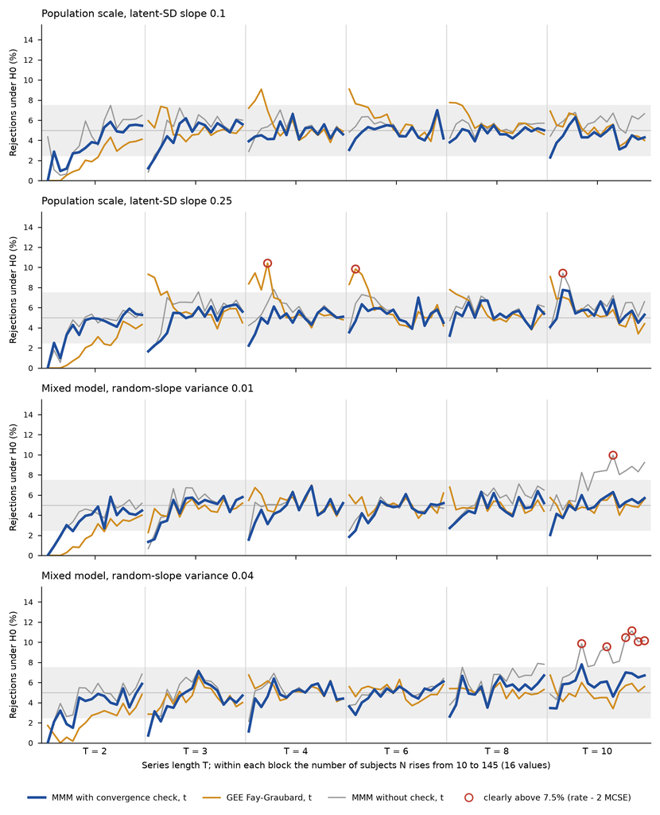

Falsi positivi sotto H0 nei 384 punti di disegno dei quattro scenari nuovi, per tre strategie con riferimento t. Banda grigia: 2,5-7,5% (Bradley). Cerchi: punti chiaramente sopra 7,5% (tasso - 2 MCSE > 7,5). 1.000 replicati per punto.

| strategia | insieme | punti | chiaramente sopra 7,5% | chiaramente sotto 2,5% | tasso massimo (%) | risponde (%) | potenza per tentativo (%) |
| --- | --- | --- | --- | --- | --- | --- | --- |
| gee_fg\|t | nuovi | 384 | 2 | 22 | 10,4 | 91,7 | 22,1 |
| gee_fg\|t | studio | 1512 | 0 | 94 | 9,0 | 92,0 | 20,1 |
| gee_fg\|t | tutti T2-3 N<=25 | 176 | 0 | 79 | 9,3 | 43,6 | 1,5 |
| gee_fg\|t | tutti T2-3 N>=35 | 468 | 0 | 37 | 7,2 | 95,1 | 5,0 |
| gee_fg\|t | tutti | 1896 | 2 | 116 | 10,4 | 91,9 | 20,5 |
| gee_md\|t | nuovi | 384 | 18 | 25 | 14,1 | 91,6 | 22,3 |
| gee_md\|t | studio | 1512 | 14 | 99 | 11,8 | 91,9 | 20,2 |
| gee_md\|t | tutti T2-3 N<=25 | 176 | 0 | 81 | 10,6 | 43,5 | 1,6 |
| gee_md\|t | tutti T2-3 N>=35 | 468 | 0 | 43 | 7,0 | 95,1 | 4,9 |
| gee_md\|t | tutti | 1896 | 32 | 124 | 14,1 | 91,8 | 20,6 |
| glmer_lrt\|n | nuovi | 384 | 0 | 8 | 7,5 | 83,3 | 26,5 |
| glmer_lrt\|n | studio | 1512 | 216 | 5 | 26,2 | 87,1 | 23,9 |
| glmer_lrt\|n | tutti T2-3 N<=25 | 176 | 52 | 7 | 15,8 | 62,7 | 5,6 |
| glmer_lrt\|n | tutti T2-3 N>=35 | 468 | 91 | 0 | 26,2 | 59,0 | 5,9 |
| glmer_lrt\|n | tutti | 1896 | 216 | 13 | 26,2 | 86,4 | 24,4 |
| mmm\|n | nuovi | 384 | 3 | 3 | 10,6 | 90,9 | 24,5 |
| mmm\|n | studio | 1512 | 1 | 15 | 10,0 | 91,0 | 22,0 |
| mmm\|n | tutti T2-3 N<=25 | 176 | 1 | 18 | 10,0 | 40,4 | 2,2 |
| mmm\|n | tutti T2-3 N>=35 | 468 | 0 | 0 | 8,8 | 93,2 | 6,4 |
| mmm\|n | tutti | 1896 | 4 | 18 | 10,6 | 91,0 | 22,5 |
| mmm\|t | nuovi | 384 | 0 | 9 | 7,8 | 90,9 | 23,3 |
| mmm\|t | studio | 1512 | 0 | 68 | 8,4 | 91,0 | 20,7 |
| mmm\|t | tutti T2-3 N<=25 | 176 | 0 | 50 | 7,8 | 40,4 | 1,5 |
| mmm\|t | tutti T2-3 N>=35 | 468 | 0 | 3 | 8,4 | 93,2 | 6,0 |
| mmm\|t | tutti | 1896 | 0 | 77 | 8,4 | 91,0 | 21,2 |

| scenario | N | T | regola usata (%) | non convergenti (%) | convergono con pendenza < 0,001 (%) | codice 3 / 4 / 5 (%) | rifiuti con la regola usata (%) |
| --- | --- | --- | --- | --- | --- | --- | --- |
| modello misto, varianza 0,01 | N10-20 | T2-3 | 55,6 | 57,0 | 8,0 | 16,7 / 0,1 / 40,3 | 1,7 |
| modello misto, varianza 0,01 | N10-20 | T4-6 | 66,0 | 47,5 | 24,1 | 11,1 / 2,6 / 33,8 | 4,4 |
| modello misto, varianza 0,01 | N10-20 | T8-10 | 57,8 | 43,5 | 14,9 | 10,1 / 20,9 / 12,5 | 5,9 |
| modello misto, varianza 0,01 | N25-55 | T2-3 | 63,0 | 53,3 | 18,1 | 13,2 / 0,6 / 39,5 | 4,5 |
| modello misto, varianza 0,01 | N25-55 | T4-6 | 52,3 | 16,9 | 36,4 | 1,6 / 2,7 / 12,5 | 5,3 |
| modello misto, varianza 0,01 | N25-55 | T8-10 | 48,0 | 34,1 | 13,9 | 2,2 / 24,0 / 7,8 | 5,5 |
| modello misto, varianza 0,01 | N65-145 | T2-3 | 60,1 | 37,4 | 24,9 | 13,8 / 1,6 / 22,0 | 5,5 |
| modello misto, varianza 0,01 | N65-145 | T4-6 | 45,0 | 8,6 | 36,4 | 0,1 / 1,8 / 6,8 | 5,4 |
| modello misto, varianza 0,01 | N65-145 | T8-10 | 36,8 | 25,0 | 11,9 | 0,4 / 18,2 / 6,4 | 5,4 |
| modello misto, varianza 0,04 | N10-20 | T2-3 | 55,7 | 56,2 | 8,3 | 16,8 / 0,1 / 39,3 | 1,6 |
| modello misto, varianza 0,04 | N10-20 | T4-6 | 62,6 | 45,4 | 22,3 | 10,8 / 2,6 / 32,1 | 4,9 |
| modello misto, varianza 0,04 | N10-20 | T8-10 | 49,3 | 38,5 | 11,5 | 8,9 / 19,4 / 10,1 | 6,3 |
| modello misto, varianza 0,04 | N25-55 | T2-3 | 63,1 | 54,5 | 17,1 | 13,3 / 0,6 / 40,6 | 4,1 |
| modello misto, varianza 0,04 | N25-55 | T4-6 | 46,1 | 15,7 | 31,1 | 1,4 / 2,6 / 11,7 | 5,9 |
| modello misto, varianza 0,04 | N25-55 | T8-10 | 31,7 | 24,8 | 6,8 | 1,6 / 16,1 / 7,2 | 6,4 |
| modello misto, varianza 0,04 | N65-145 | T2-3 | 58,9 | 36,8 | 24,0 | 13,4 / 1,5 / 21,9 | 5,6 |
| modello misto, varianza 0,04 | N65-145 | T4-6 | 36,8 | 7,0 | 29,8 | 0,0 / 1,3 / 5,7 | 5,8 |
| modello misto, varianza 0,04 | N65-145 | T8-10 | 19,2 | 15,8 | 3,4 | 0,2 / 8,4 / 7,2 | 5,6 |
| scala della popolazione, pendenza 0,1 | N10-20 | T2-3 | 57,3 | 57,6 | 6,3 | 30,4 / 0,2 / 27,0 | 1,6 |
| scala della popolazione, pendenza 0,1 | N10-20 | T4-6 | 64,9 | 51,4 | 18,0 | 22,7 / 1,7 / 26,9 | 5,2 |
| scala della popolazione, pendenza 0,1 | N10-20 | T8-10 | 51,7 | 41,9 | 10,6 | 16,4 / 15,1 / 10,3 | 5,1 |
| scala della popolazione, pendenza 0,1 | N25-55 | T2-3 | 64,3 | 56,6 | 13,9 | 25,3 / 0,7 / 30,5 | 4,2 |
| scala della popolazione, pendenza 0,1 | N25-55 | T4-6 | 46,8 | 19,7 | 27,7 | 6,8 / 2,0 / 10,8 | 5,6 |
| scala della popolazione, pendenza 0,1 | N25-55 | T8-10 | 33,7 | 23,8 | 9,9 | 3,4 / 14,5 / 6,0 | 5,2 |
| scala della popolazione, pendenza 0,1 | N65-145 | T2-3 | 58,6 | 38,0 | 21,8 | 17,8 / 2,3 / 17,9 | 5,7 |
| scala della popolazione, pendenza 0,1 | N65-145 | T4-6 | 35,3 | 6,8 | 28,5 | 0,5 / 1,0 / 5,4 | 5,3 |
| scala della popolazione, pendenza 0,1 | N65-145 | T8-10 | 20,8 | 14,0 | 6,8 | 0,4 / 8,7 / 4,9 | 5,4 |
| scala della popolazione, pendenza 0,25 | N10-20 | T2-3 | 56,1 | 57,7 | 5,5 | 30,4 / 0,2 / 27,0 | 1,4 |
| scala della popolazione, pendenza 0,25 | N10-20 | T4-6 | 61,8 | 53,7 | 12,6 | 26,8 / 1,7 / 25,3 | 5,1 |
| scala della popolazione, pendenza 0,25 | N10-20 | T8-10 | 44,0 | 38,9 | 6,3 | 19,4 / 11,6 / 7,9 | 6,3 |
| scala della popolazione, pendenza 0,25 | N25-55 | T2-3 | 63,8 | 56,3 | 13,0 | 26,5 / 0,9 / 28,9 | 4,3 |
| scala della popolazione, pendenza 0,25 | N25-55 | T4-6 | 38,0 | 19,9 | 18,7 | 9,0 / 1,3 / 9,5 | 6,8 |
| scala della popolazione, pendenza 0,25 | N25-55 | T8-10 | 17,8 | 14,6 | 3,2 | 3,8 / 7,6 / 3,3 | 5,8 |
| scala della popolazione, pendenza 0,25 | N65-145 | T2-3 | 56,8 | 38,9 | 19,2 | 19,3 / 2,2 / 17,4 | 5,7 |
| scala della popolazione, pendenza 0,25 | N65-145 | T4-6 | 20,7 | 4,1 | 16,6 | 0,8 / 0,3 / 2,9 | 5,7 |
| scala della popolazione, pendenza 0,25 | N65-145 | T8-10 | 6,3 | 5,5 | 0,8 | 0,2 / 2,6 / 2,7 | 5,7 |

## 4. Dubbi aperti durante il lavoro e come si sono chiusi

1. **Tre errori degli strumenti, corretti.** (a) Lo script di costruzione della parte A falliva su una colonna di join senza prefisso: corretto prima di ogni numero. (b) GB1 confrontava le formule con il loro ambiente, che e’ diverso a ogni chiamata, e risultava sempre “diverso”: ora le confronta come testo; il cancello passa con 32 confronti su 32. (c) GB4 non creava le combinazioni metodo-punto senza righe (n = 0), che lo studio invece ha: ora le crea; il cancello passa con 3.072 righe su 3.072.
2. **GB3 come scritto e’ fallito; spiegato.** I 365 replicati senza una riga sono analisi che restituiscono un fit senza il termine testato (sez. 1, voce GB3b): il controllo non contava questo esito. Le misure non cambiano, perche’ quei fit sono non utilizzabili in ogni caso.
3. **PB1 e PB3 smentite, PB4 indeterminata: spiegate** nella sezione “Esito delle attese” del file dello step e nelle tabelle della sezione 3.
4. **Temperatura del server.** Con circa 33 processi la CPU ha raggiunto 94 C; il run e’ stato portato a 16 processi e poi regolato da un controllo automatico (sopra 90 C meno 4, sotto 82 C piu’ 2, massimo 28). Nessun blocco interrotto, salvo i blocchi in corso al limite di tempo del primo lavoro (riscritti dal rilancio).
5. **Controllo del codice su dati parziali.** Prima della fine del run lo script di aggregazione e’ stato provato su 300 blocchi; l’ultima riga stampata mostrava valori parziali delle previsioni. Le attese erano gia’ committate e non sono cambiate.

## 5. Cosa e’ girato

| cosa | script | durata |
| --- | --- | --- |
| Parte A: fit per la soglia 0,01 | R/s6b/s6b_thr_job.sh, s6b_thr_run.R | 5,3 min (48 processi) |
| Parte A: varianti e catena S4-S6 | R/s6b/s6b_thr_pipeline.sh, s6b_thr_build.R | circa 70 min |
| Parte A: confronto | R/s6b/s6b_thr_compare.R, s6b_thr_flips.R | pochi minuti |
| Parte B: cancelli prima del run | R/s6b/s6b_ns_gates_pre.R | circa 7 min |
| Parte B: run (768.000 dataset) | R/s6b/s6b_ns_run.R, s6b_ns_common.R, s6b_thermal_guard.sh | 23,1 h (16-28 processi) |
| Parte B: aggregazione e diagnostica | R/s6b/s6b_ns_agg.R, s6b_ns_agg_lib.R, s6b_ns_diag.R, s6b_rule_all.R | pochi minuti |

Pre-registrazione: commit `9f298a3` (parte A), `2ff6dae` (parte B e decisione D-34). Risultati della parte A: commit `baf1a55`. md5: `tables/V4_S6b_md5_check.csv`.

## Appendice

### A1. Da dove vengono i numeri del riassunto

| frase | fonte | valore |
| --- | --- | --- |
| circa 20.000 dei 1,69 milioni di dataset | V4_S6b_thr_inventory.csv righe 2-3; cc_all.rds 1.685.204 fit | 21879; 19962 |
| si spostano al più di circa un millesimo di test su 100 | V4_S6b_thr_preds.csv PA1-PA3, \|est\| massimo | 0,0012 |
| nessuna delle 156 frasi cambia | V4_S6b_thr_preds.csv PA6 | 0/0 |
| 768.000 dataset; 384 situazioni nuove | V4_S6b_ns_gates_post.csv GB3; V4_S6b_ns_rule_safety_dp.csv | 768000 replicates with rows; 384 punti |
| deviazione standard latente da 1 a 1,9 o 3,25; 10 o 40 volte piu’ variabile | D-34; generatori: sigma = (1; 0,1), (1; 0,25), 1 + s*9; varianza 0,01 e 0,04 contro 0,001 | 1,9; 3,25; 10; 40 |
| non supera mai chiaramente 7,5 (scenari nuovi) | V4_S6b_ns_preds.csv PB2 | 0 |
| in media da 5,2 a 5,8 su 100 | V4_S6b_ns_preds.csv PB4 | 5,21-5,84 |
| senza correzione: 8 situazioni | V4_S6b_ns_rule_safety_dp.csv, mmm_nocc\|t, hi | 8 |
| un dataset su tre fino a uno su due | V4_S6b_ns_preds.csv PB1 (H0) | 35,6-51,4 |
| con molti soggetti e 8-10 visite 6-37 su 100 | V4_S6b_ns_diag_fallback.csv, H0, N65-145, T8-10 | 6,3-36,8 |
| dove interviene, falsi positivi 5 su 100 | V4_S6b_ns_fallback.csv rej_B (H0) | 5,00-5,23 |
| capacita’ cala meno di mezzo test su 100 | V4_S6b_ns_preds.csv PB6 | -0,30 / -0,07 |
| Fay e Graubard da 7 a 10 su 100 con fino a 25 soggetti | V4_S6b_ns_rule_safety_dp.csv, gee_fg\|t, GenBinaryY M7, N <= 25, T >= 3 | 6,7-10,4 |
| due situazioni, 10 su 100 | V4_S6b_ns_rule_safety_dp.csv, gee_fg\|t, hi | 9,8; 10,4 |
| unica strategia mai chiaramente sopra (1.896) | V4_S6b_rule_all.csv, tutti, all | mmm\|t 0; gee_fg\|t 2 |
| 91 contro 92; 77 contro 116; 21 contro 20,5 | V4_S6b_rule_all.csv mmm\|t e gee_fg\|t, tutti, all | 91,0/91,9; 77/116; 21,2/20,5 |
| 2-3 visite, fino a 25 soggetti: 4 su 10, meno di 2 su 100 | V4_S6b_rule_all.csv, T2-3 N<=25 | risponde 40,4/43,6; potenza 1,46/1,51 |
| valore vero fino a -0,008 | V4_S6b_ns_truth.csv GLMM-native M7 T 10 manual | -0,0079 |
| 23 ore | run_progress.log: 16,7 h + 6,38 h | 23,1 h |